Random forest

```python
# Choose the type of classifier.
rf_tuned = RandomForestClassifier(class_weight={0:0.2,1:0.8},random_state=1)

parameters = {
                'max_depth': list(np.arange(3,10,1)),
                'max_features': np.arange(0.6,1.1,0.1),
                'max_samples': np.arange(0.7,1.1,0.1),
                'min_samples_split': np.arange(2, 20, 5),
                'min_impurity_decrease': [0.0001,0.001,0.01,0.1]
}


# Type of scoring used to compare parameter combinations
scorer = metrics.make_scorer(metrics.recall_score)

# Run the grid search
grid_obj = GridSearchCV(rf_tuned, parameters, scoring=scorer,cv=5,n_jobs=-1)
grid_obj = grid_obj.fit(X_train, y_train)

# Set the clf to the best combination of parameters
rf_tuned = grid_obj.best_estimator_

# Fit the best algorithm to the data.
rf_tuned.fit(X_train, y_train)
```

```
RandomForestClassifier(class_weight={0: 0.2, 1: 0.8}, max_depth=9,
                       max_features=0.7, max_samples=0.9999999999999999,
                       min_impurity_decrease=0.001, min_samples_split=17,
                       random_state=1)
```

```
Training performance:
    Accuracy    Recall  Precision        F1
0  0.904999  0.875776   0.697157  0.776325
Testing performance:
    Accuracy    Recall  Precision        F1
0  0.868439  0.699275   0.636964  0.666667
```

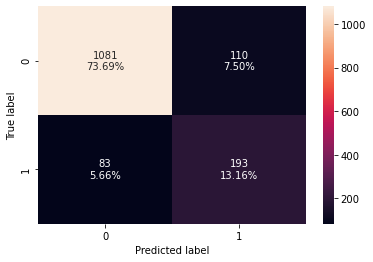

```python
#Calculating different metrics
rf_tuned_model_train_perf=model_performance_classification_sklearn(rf_tuned,X_train,y_train)
print("Training performance:\n",rf_tuned_model_train_perf)
rf_tuned_model_test_perf=model_performance_classification_sklearn(rf_tuned,X_test,y_test)
print("Testing performance:\n",rf_tuned_model_test_perf)

#Creating confusion matrix
confusion_matrix_sklearn(rf_tuned, X_test, y_test)
```

This is really good, recall still somewhat lower than I'd like but it is better and accuracy is way up bagging

```python
# Choose the type of classifier.
bagging_estimator_tuned = BaggingClassifier(random_state=1)

# Grid of parameters to choose from
parameters = {'max_samples': [0.7,0.8,0.9,1],
              'max_features': [0.7,0.8,0.9,1],
              'n_estimators' : [10,20,30,40,50],
             }

# Type of scoring used to compare parameter combinations
acc_scorer = metrics.make_scorer(metrics.recall_score)

# Run the grid search
grid_obj = GridSearchCV(bagging_estimator_tuned, parameters, scoring=acc_scorer,cv=5)
grid_obj = grid_obj.fit(X_train, y_train)

# Set the clf to the best combination of parameters
bagging_estimator_tuned = grid_obj.best_estimator_

# Fit the best algorithm to the data.
bagging_estimator_tuned.fit(X_train, y_train)
```

```
BaggingClassifier(max_features=0.9, max_samples=0.9, n_estimators=50,
                  random_state=1)
```

```
Training performance:
    Accuracy  Recall  Precision   F1
0       1.0     1.0        1.0  1.0
Testing performance:
    Accuracy    Recall  Precision        F1
0  0.920245  0.630435   0.920635  0.748387
```

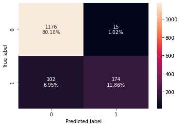

```python
bagging_estimator_tuned_model_train_perf=model_performance_classification_sklearn(bagging_estimator_tuned,X_train,y_train)
print("Training performance:\n",bagging_estimator_tuned_model_train_perf)
bagging_estimator_tuned_model_test_perf=model_performance_classification_sklearn(bagging_estimator_tuned,X_test,y_test)
print("Testing performance:\n",bagging_estimator_tuned_model_test_perf)

#Creating confusion matrix
confusion_matrix_sklearn(bagging_estimator_tuned, X_test, y_test)
```

not great accuracy high though

```python
# training performance comparison

models_train_comp_df = pd.concat(
    [dtree_model_test_perf.T,dtree_estimator_model_test_perf.T,rf_estimator_model_test_perf.T,rf_tuned_model_test_perf.T,
     bagging_classifier_model_test_perf.T,bagging_estimator_tuned_model_test_perf.T],
    axis=1,
)
models_train_comp_df.columns = [
    "Decision Tree Estimator",
    "Decision Tree Tuned",
    "Random Forest Estimator",
    "Random Forest Tuned",
    "Bagging Classifier",
    "Bagging Estimator Tuned"]
print("Training performance comparison:")
models_train_comp_df
```

```
Training performance comparison:
```

|  | Decision Tree Estimator | Decision Tree Tuned | Random Forest Estimator | Random Forest Tuned | Bagging Classifier | Bagging Estimator Tuned |
| --- | --- | --- | --- | --- | --- | --- |
| Accuracy | 0.885481 | 0.790729 | 0.920245 | 0.868439 | 0.904567 | 0.920245 |
| Recall | 0.634058 | 0.659420 | 0.615942 | 0.699275 | 0.594203 | 0.630435 |
| Precision | 0.723140 | 0.460759 | 0.939227 | 0.636964 | 0.854167 | 0.920635 |
| F1 | 0.675676 | 0.542474 | 0.743982 | 0.666667 | 0.700855 | 0.748387 |

Tuned rf is the best

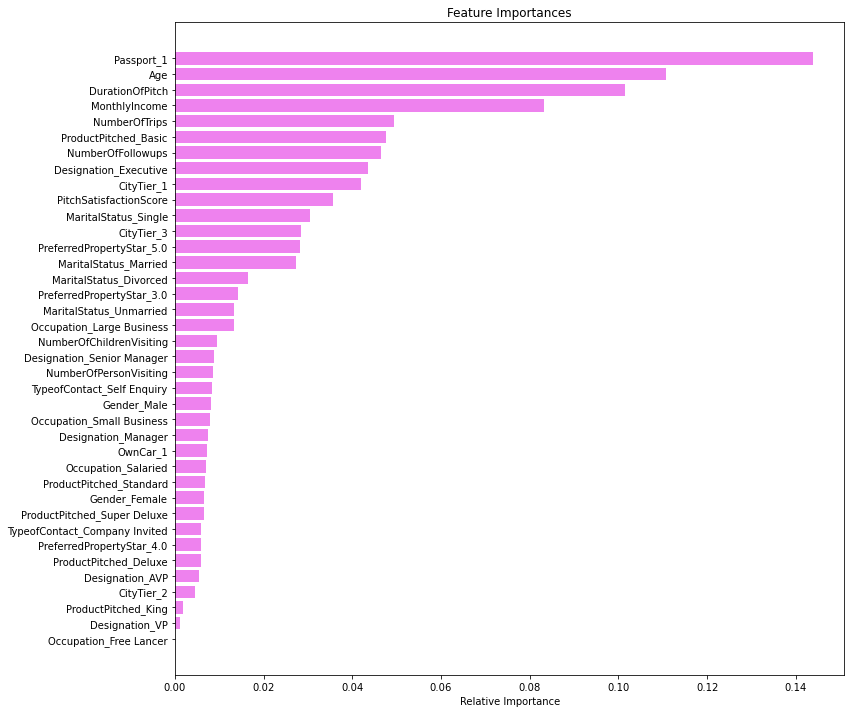

```python
feature_names = X_train.columns
importances = rf_tuned.feature_importances_
indices = np.argsort(importances)

plt.figure(figsize=(12,12))
plt.title('Feature Importances')
plt.barh(range(len(indices)), importances[indices], color='violet', align='center')
plt.yticks(range(len(indices)), [feature_names[i] for i in indices])
plt.xlabel('Relative Importance')
plt.show()
```

According to these results having a passport will positively increase the likelyhood of accpeted **target people who do have passport** Duration of pitch had a positive relationship with likelyhood and we see it is important here **spent more time** Age and income both had negative relationships with likelyhood above and are both important here **target lower income young people maybe**

Model building - Boosting

- Build Adaboost, GradientBoost, XGBoost, and Stacking classifiers - Comment on model performance

```python
from sklearn.ensemble import AdaBoostClassifier, GradientBoostingClassifier
from xgboost import XGBClassifier
from sklearn.ensemble import StackingClassifier
from sklearn.tree import DecisionTreeClassifier

# Libtune to tune model, get different metric scores
from sklearn import metrics
from sklearn.metrics import confusion_matrix, classification_report, accuracy_score, precision_score, recall_score, f1_score, roc_auc_score
from sklearn.model_selection import GridSearchCV
```

ADA boosting

```
   Accuracy    Recall  Precision        F1
0  0.845659  0.310559   0.704225  0.431034
   Accuracy    Recall  Precision        F1
0  0.852079  0.318841   0.752137  0.447837
```

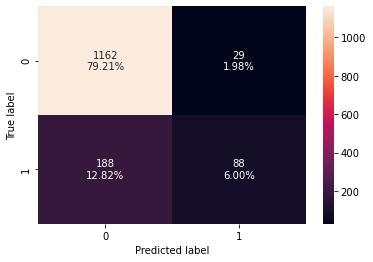

```python
#Fitting the model
ab_classifier = AdaBoostClassifier(random_state=1)
ab_classifier.fit(X_train,y_train)

#Calculating different metrics
ab_classifier_model_train_perf=model_performance_classification_sklearn(ab_classifier,X_train,y_train)
print(ab_classifier_model_train_perf)
ab_classifier_model_test_perf=model_performance_classification_sklearn(ab_classifier,X_test,y_test)
print(ab_classifier_model_test_perf)

#Creating confusion matrix
confusion_matrix_sklearn(ab_classifier,X_test,y_test)
```

No over fitting but we do also have very bad recall. Few false +

Gradient boosting

```
Training performance:
    Accuracy   Recall  Precision        F1
0  0.886583  0.46118   0.878698  0.604888
Testing performance:
    Accuracy   Recall  Precision        F1
0  0.869802  0.40942   0.801418  0.541966
```

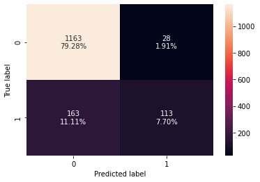

```python
#Fitting the model
gb_classifier = GradientBoostingClassifier(random_state=1)
gb_classifier.fit(X_train,y_train)

#Calculating different metrics
gb_classifier_model_train_perf=model_performance_classification_sklearn(gb_classifier,X_train,y_train)
print("Training performance:\n",gb_classifier_model_train_perf)
gb_classifier_model_test_perf=model_performance_classification_sklearn(gb_classifier,X_test,y_test)
print("Testing performance:\n",gb_classifier_model_test_perf)

#Creating confusion matrix
confusion_matrix_sklearn(gb_classifier,X_test,y_test)
```

Recall is SLIGHLY better. Few false +

XG boosting

```
Training performance:
    Accuracy    Recall  Precision        F1
0  0.999415  0.996894        1.0  0.998445
Testing performance:
    Accuracy    Recall  Precision        F1
0  0.922972  0.706522   0.859031  0.775348
```

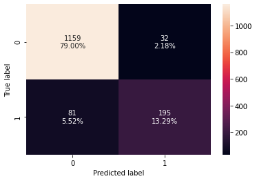

```python
#Fitting the model
xgb_classifier = XGBClassifier(random_state=1, eval_metric='logloss')
xgb_classifier.fit(X_train,y_train)

#Calculating different metrics
xgb_classifier_model_train_perf=model_performance_classification_sklearn(xgb_classifier,X_train,y_train)
print("Training performance:\n",xgb_classifier_model_train_perf)
xgb_classifier_model_test_perf=model_performance_classification_sklearn(xgb_classifier,X_test,y_test)
print("Testing performance:\n",xgb_classifier_model_test_perf)

#Creating confusion matrix
confusion_matrix_sklearn(xgb_classifier,X_test,y_test)
```

Recall is GREAT though there seems to be some overfitting

Stacking (without tuned)

```python
estimators = [('Random Forest',rf_estimator), ('Gradient Boosting',gb_classifier), ('Decision Tree',dtree_estimator)]

final_estimator = xgb_classifier

stacking_classifier= StackingClassifier(estimators=estimators,final_estimator=final_estimator)

stacking_classifier.fit(X_train,y_train)
```

```
StackingClassifier(estimators=[('Random Forest',
                                RandomForestClassifier(random_state=1)),
                               ('Gradient Boosting',
                                GradientBoostingClassifier(random_state=1)),
                               ('Decision Tree',
                                DecisionTreeClassifier(class_weight={0: 0.2,
                                                                     1: 0.8},
                                                       max_depth=5,
                                                       max_leaf_nodes=15,
                                                       min_impurity_decrease=0.0001,
                                                       min_samples_leaf=5,
                                                       random_state=1))],
                   final_estimator=XGBClassifier(base_sc...
                                                 importance_type=None,
                                                 interaction_constraints='',
                                                 learning_rate=0.300000012,
                                                 max_delta_step=0, max_depth=6,
                                                 min_child_weight=1,
                                                 missing=nan,
                                                 monotone_constraints='()',
                                                 n_estimators=100, n_jobs=8,
                                                 num_parallel_tree=1,
                                                 predictor='auto',
                                                 random_state=1, reg_alpha=0,
                                                 reg_lambda=1,
                                                 scale_pos_weight=1,
                                                 subsample=1,
                                                 tree_method='exact',
                                                 validate_parameters=1,
                                                 verbosity=None))
```

```
Training performance:
    Accuracy  Recall  Precision   F1
0       1.0     1.0        1.0  1.0
Testing performance:
    Accuracy    Recall  Precision        F1
0  0.929789  0.786232   0.831418  0.808194
```

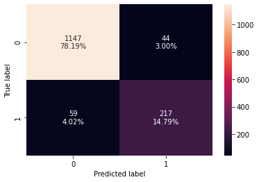

```python
#Calculating different metrics
stacking_classifier_model_train_perf=model_performance_classification_sklearn(stacking_classifier,X_train,y_train)
print("Training performance:\n",stacking_classifier_model_train_perf)
stacking_classifier_model_test_perf=model_performance_classification_sklearn(stacking_classifier,X_test,y_test)
print("Testing performance:\n",stacking_classifier_model_test_perf)

#Creating confusion matrix
confusion_matrix_sklearn(stacking_classifier,X_test,y_test)
```

Bad overfitting but really good recall (compared to other models atleast)

Model performance improvement - Boosting

- Comment on which metric is right for model performance evaluation and why? - Comment on the model performance after tuning the AdaBoost, and Gradient Boosting classifier on the appropriate metric to improve the model performance. * Please note XGBoost can take a significantly longer time to run, so if you have time complexity issues then you can avoid tuning XGBoost.

ADA

```python
# Choose the type of classifier.
abc_tuned = AdaBoostClassifier(random_state=1)

# Grid of parameters to choose from
parameters = {
    #Let's try different max_depth for base_estimator
    "base_estimator":[DecisionTreeClassifier(max_depth=1),DecisionTreeClassifier(max_depth=2),
                      DecisionTreeClassifier(max_depth=3)],
    "n_estimators": np.arange(10,110,10),
    "learning_rate":np.arange(0.1,2,0.1)
}

# Type of scoring used to compare parameter  combinations
scorer = metrics.make_scorer(metrics.recall_score)

# Run the grid search
grid_obj = GridSearchCV(abc_tuned, parameters, scoring=scorer,cv=5)
grid_obj = grid_obj.fit(X_train, y_train)

# Set the clf to the best combination of parameters
abc_tuned = grid_obj.best_estimator_

# Fit the best algorithm to the data.
abc_tuned.fit(X_train, y_train)
```

```
AdaBoostClassifier(base_estimator=DecisionTreeClassifier(max_depth=3),
                   learning_rate=1.3000000000000003, n_estimators=100,
                   random_state=1)
```

```
   Accuracy    Recall  Precision        F1
0  0.990061  0.964286   0.982595  0.973354
   Accuracy    Recall  Precision        F1
0  0.886162  0.644928   0.720648  0.680688
```

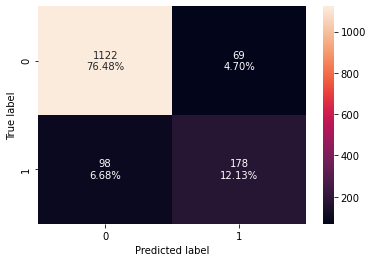

```python
#Calculating different metrics
abc_tuned_model_train_perf=model_performance_classification_sklearn(abc_tuned,X_train,y_train)
print(abc_tuned_model_train_perf)
abc_tuned_model_test_perf=model_performance_classification_sklearn(abc_tuned,X_test,y_test)
print(abc_tuned_model_test_perf)

#Creating confusion matrix
confusion_matrix_sklearn(abc_tuned,X_test,y_test)
```

```python
# Choose the type of classifier.
gbc_tuned = GradientBoostingClassifier(init=AdaBoostClassifier(random_state=1),random_state=1)

# Grid of parameters to choose from
parameters = {
    "n_estimators": [100,150,200,250],
    "subsample":[0.8,0.9,1],
    "max_features":[0.7,0.8,0.9,1]
}

# Type of scoring used to compare parameter combinations
scorer = metrics.make_scorer(metrics.recall_score)

# Run the grid search
grid_obj = GridSearchCV(gbc_tuned, parameters, scoring=scorer,cv=5)
grid_obj = grid_obj.fit(X_train, y_train)

# Set the clf to the best combination of parameters
gbc_tuned = grid_obj.best_estimator_

# Fit the best algorithm to the data.
```

```
Training performance:
    Accuracy    Recall  Precision        F1
0  0.920491  0.619565    0.93662  0.745794
Testing performance:
    Accuracy    Recall  Precision        F1
0  0.873892  0.460145   0.779141  0.578588
```

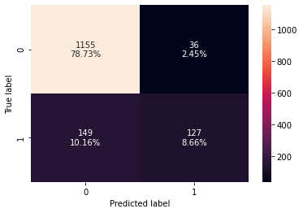

```python
gbc_tuned_model_train_perf=model_performance_classification_sklearn(gbc_tuned,X_train,y_train)
print("Training performance:\n",gbc_tuned_model_train_perf)
gbc_tuned_model_test_perf=model_performance_classification_sklearn(gbc_tuned,X_test,y_test)
print("Testing performance:\n",gbc_tuned_model_test_perf)

#Creating confusion matrix
confusion_matrix_sklearn(gbc_tuned,X_test,y_test)
```

SOMNE overfitting and bad recall

XGB

```
Training performance:
    Accuracy    Recall  Precision        F1
0  0.956153  0.986025   0.818299  0.894366
Testing performance:
    Accuracy    Recall  Precision        F1
0  0.889571  0.818841   0.668639  0.736156
```

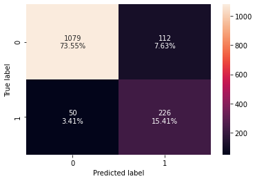

```python
# Choose the type of classifier.
xgb_tuned = XGBClassifier(random_state=1, eval_metric='logloss')

# Grid of parameters to choose from
parameters = {
    "n_estimators": [10,30,50],
    "scale_pos_weight":[1,2,5],
    "subsample":[0.7,0.9,1],
    "learning_rate":[0.05, 0.1,0.2],
    "colsample_bytree":[0.7,0.9,1],
    "colsample_bylevel":[0.5,0.7,1]
}

# Type of scoring used to compare parameter combinations
scorer = metrics.make_scorer(metrics.recall_score)

# Run the grid search
grid_obj = GridSearchCV(xgb_tuned, parameters,scoring=scorer,cv=5)
grid_obj = grid_obj.fit(X_train, y_train)

# Set the clf to the best combination of parameters
xgb_tuned = grid_obj.best_estimator_

# Fit the best algorithm to the data.
xgb_tuned.fit(X_train, y_train)
#Calculating different metrics
xgb_tuned_model_train_perf=model_performance_classification_sklearn(xgb_tuned,X_train,y_train)
print("Training performance:\n",xgb_tuned_model_train_perf)
xgb_tuned_model_test_perf=model_performance_classification_sklearn(xgb_tuned,X_test,y_test)
print("Testing performance:\n",xgb_tuned_model_test_perf)

#Creating confusion matrix
confusion_matrix_sklearn(xgb_tuned,X_test,y_test)
```

Amazing! Still some overfititng but by far the best recall I've seen.

Tuned stacking

```
Training performance:
    Accuracy    Recall  Precision       F1
0  0.881321  0.953416   0.620202  0.75153
Testing performance:
    Accuracy    Recall  Precision        F1
0  0.818678  0.804348   0.511521  0.625352
```

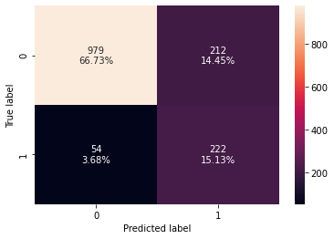

```python
estimators = [('Random Forest',rf_tuned), ('Gradient Boosting',gbc_tuned), ('Decision Tree',dtree_estimator)]

final_estimator = xgb_tuned
stacking_classifier= StackingClassifier(estimators=estimators,final_estimator=final_estimator)

stacking_classifier.fit(X_train,y_train)
#Calculating different metrics
stacking_classifier_model_train_perf=model_performance_classification_sklearn(stacking_classifier,X_train,y_train)
print("Training performance:\n",stacking_classifier_model_train_perf)
stacking_classifier_model_test_perf=model_performance_classification_sklearn(stacking_classifier,X_test,y_test)
print("Testing performance:\n",stacking_classifier_model_test_perf)

#Creating confusion matrix
confusion_matrix_sklearn(stacking_classifier,X_test,y_test)
```

Slighly worse than XGB

Compare

```python
# training performance comparison

models_test_comp_df2 = pd.concat(
    [ab_classifier_model_test_perf.T,
     abc_tuned_model_test_perf.T,
     gb_classifier_model_test_perf.T,
     gbc_tuned_model_test_perf.T,
     xgb_classifier_model_test_perf.T,
     xgb_tuned_model_test_perf.T,
     stacking_classifier_model_test_perf.T],
    axis=1,
)
models_test_comp_df2.columns = [
    "Adaboost Classifier",
    "Adabosst Classifier Tuned",
    "Gradient Boost Classifier",
    "Gradient Boost Classifier Tuned",
    "XGBoost Classifier",
    "XGBoost Classifier Tuned",
    "Stacking Classifier"]
print("Training performance comparison:")
models_test_comp_df2
```

```
Training performance comparison:
```

|  | Adaboost Classifier | Adabosst Classifier Tuned | Gradient Boost Classifier | Gradient Boost Classifier Tuned | XGBoost Classifier | XGBoost Classifier Tuned | Stacking Classifier |
| --- | --- | --- | --- | --- | --- | --- | --- |
| Accuracy | 0.852079 | 0.886162 | 0.869802 | 0.873892 | 0.922972 | 0.889571 | 0.818678 |
| Recall | 0.318841 | 0.644928 | 0.409420 | 0.460145 | 0.706522 | 0.818841 | 0.804348 |
| Precision | 0.752137 | 0.720648 | 0.801418 | 0.779141 | 0.859031 | 0.668639 | 0.511521 |
| F1 | 0.447837 | 0.680688 | 0.541966 | 0.578588 | 0.775348 | 0.736156 | 0.625352 |

Clearly tuned XGB is the best. it even beats out the best from bagging and foirest

Actionable Insights & Recommendations

- Compare model performance on various metrics. - Conclude with the key takeaways - What would your advice be to grow the business?

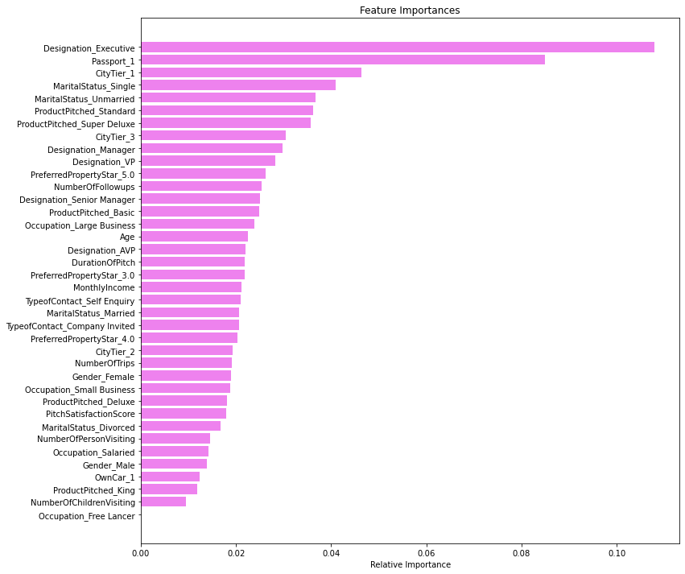

```python
feature_names = X_train.columns
importances = xgb_tuned.feature_importances_
indices = np.argsort(importances)

plt.figure(figsize=(12,12))
plt.title('Feature Importances')
plt.barh(range(len(indices)), importances[indices], color='violet', align='center')
plt.yticks(range(len(indices)), [feature_names[i] for i in indices])
plt.xlabel('Relative Importance')
plt.show()
```

**Conclusion** (Super_delux seems to be the lasty ruly important) Designation executive: we saw earlier that these peopl are more liekly to accept, so with it's importance being super high, I saw we focus on these people **Executivews are more likely to buy our new poackage** City tier: those in tier 1 citiews seem like better customers. With it's importance *customers from tier one cities MAY be more liekly to buy **Marital status: we say this had a lot of idfference earlier, so** customers who are single or unmarried are mor likely to buy than those with a family ot spouse **Product pitched: we saw this having difference earlier too: if we ppitch standard or super deluxe we will hzve more intesest** focus on standard and super delux** Overall: focus on people wh are unmarried/single, working as executives, and who do have passports. Do not focus too much of call length orfollow ups, instead focus on pitching standard and/or super delkuxe product packages We also say standard was popular with senior managers and super deluxe with AVVP, so focus on those groups too. Execs like basic packages, so also pitch that to them

Other insight: monthly income isn't as important As I would have tough, or is occupation. Keep that in mind.